# 1- Simple_Linear_Regression

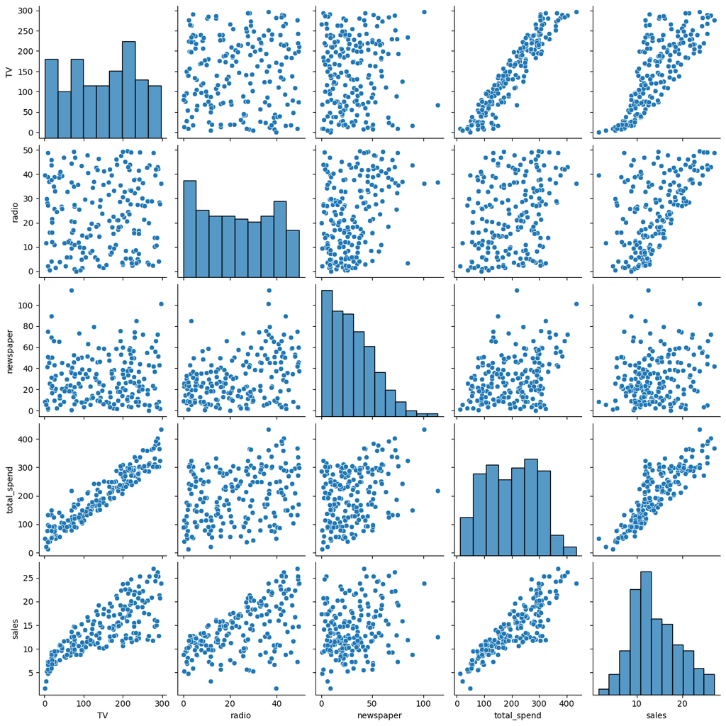

```python
sns.pairplot(df);
```

```python
import scipy.stats as stats
```

**Which Feature is Suitable for Linear Regression ?**

```python
for i in df.drop(columns = "sales"):
    print(f"corr between sales and {i:<12}: {df.sales.corr(df[i])}")

# Korelasyonları metin olarak yazdır
```

```
corr between sales and TV          : 0.7822244248616061
corr between sales and radio       : 0.5762225745710551
corr between sales and newspaper   : 0.22829902637616528
corr between sales and total_spend : 0.8677123027017427
```

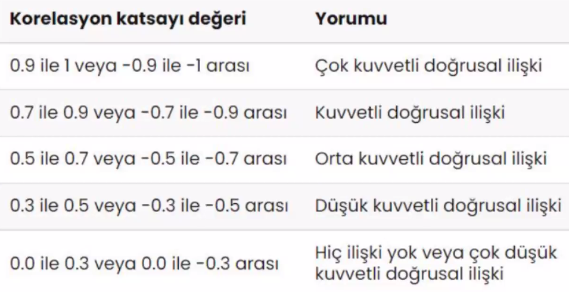

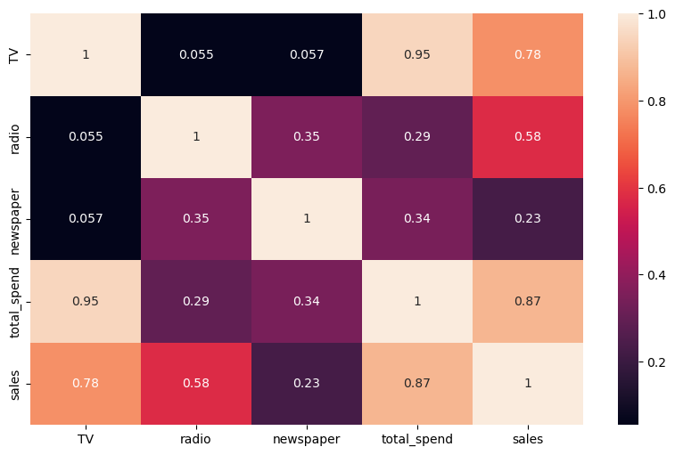

```python
sns.heatmap(df.corr(), annot=True);
```

```python
df1 = df[["total_spend", "sales"]]
df1.head()

# total_spend'e göre df oluşturduk
```

|  | total_spend | sales |
| --- | --- | --- |
| 0 | 337.1 | 22.1 |
| 1 | 128.9 | 10.4 |
| 2 | 132.4 | 9.3 |
| 3 | 251.3 | 18.5 |
| 4 | 250.0 | 12.9 |

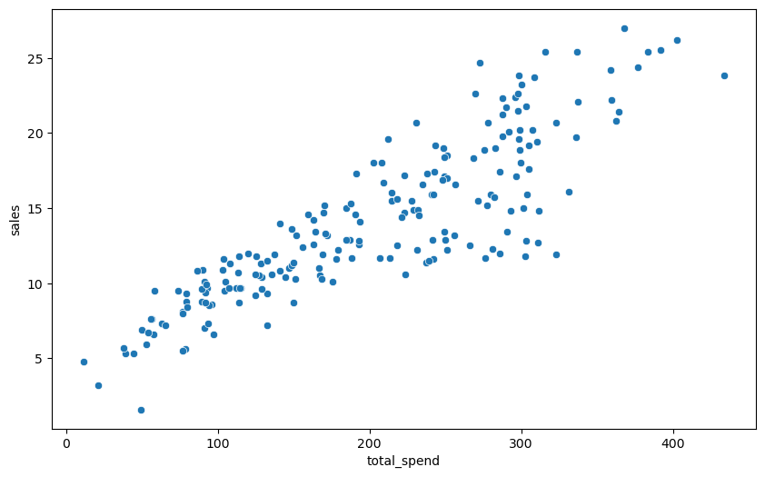

```python
sns.scatterplot(x = "total_spend", y = "sales", data = df1);
```

ScatterPlot'a baktığımızda *Pozitif Yönlü Linear Bir Correlation* olduğunu görüyoruz.

**Correlation Between Independent Variable and Dependent Variable**

```python
corr = df.sales.corr(df.total_spend)
corr
```

```
0.8677123027017427
```

```python
df["total_spend"].corr(df["sales"])
```

```
0.8677123027017427
```

**Coefficant of Determination (R2)**

```python
R2_score = corr**2 # Bu yöntemi yalnızca simple linear regression'da kullanıyoruz
R2_score

# R2 Score'una baktığımızda target variable'daki değişimin %75'ini açıklayabildiğimizi görüyoruz.
```

```
0.7529246402599608
```

# Linear Regression

## Least Square Error (LSE) ile Line of Best Fit Seçimi

**Least Square Error (LSE)**:

- Bir veri setine en iyi uyan doğrusal veya doğrusal olmayan bir modeli bulmak için kullanılır. Temelde, bir dizi gözleme dayanarak bir modelin tahminlerinin gerçek değerlerden ne kadar farklı olduğunun bir ölçüsüdür.
- Least Square Error yöntemi, modelin tahmin ettiği değerler ile gerçek değerler arasındaki farkların karelerinin toplamını minimize ederek çalışır.
- Matematiksel olarak, modelin tahmin ettiği değerler ile gerçek değerler arasındaki farkların kareleri toplamının en küçük olduğu parametre değerlerini bulmayı amaçlar.

**LSE Ne İşimize Yarar ?**

- *Modelleme ve Tahmin*: En Küçük Kareler Hatası, veriler üzerine bir model kurarak bu modelin gelecekteki verileri ne kadar iyi tahmin edebileceğini ölçmek için kullanılır.
- *Parametre Tahmini*: Bir modelin parametrelerini, modelin verilere en iyi nasıl uyduğunu belirleyerek tahmin etmek için kullanılır. Bu, modelin doğruluğunu artırır ve daha güvenilir tahminler yapmasını sağlar.
- *Modelin İyiliğinin Ölçülmes*i: Bir modelin veri setine ne kadar iyi uyduğunu değerlendirmek için kullanılır. En Küçük Kareler Hatası ne kadar düşükse, model o kadar iyi bir uyum sağlamış demektir.
- *Optimizasyon*: Makine öğrenmesi ve yapay zeka uygulamalarında, modelin performansını artırmak için parametre ayarlamaları yapılırken bir optimizasyon kriteri olarak kullanılır.

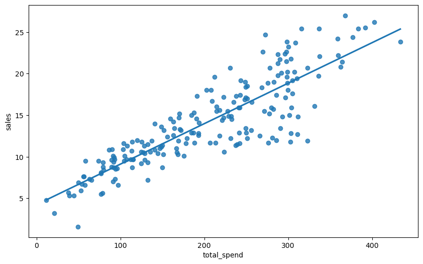

```python
sns.regplot(x="total_spend", y="sales", data=df1, ci=None);
```

## **Spliting the Dataset into** *X (Independent Variables)* and *y ( Dependent Variables)*

*y = b1* X + b0*

**y = bağımlı değişken = target variable = dependent variable**

**b1 = katsayı/eğim, slope -∞ < 0 < +∞**

**X = bağımsız değişken /feature, independent variable**

**b0 = otonom parametre / intercept /başlangıç parametresi -∞ < 0 < +∞**

```python
X = df["total_spend"] # Features
y = df["sales"] # Target Variable
```

y_pred = b1X + b0

b1 = X'in katsayısı (total_spend)

b0 = X sıfır iken y'nin aldığı değer

```python
np.polyfit(X, y, deg=1) # 1. Dereceden Polinomik Fonksiyon

# İçine independent ve dependent variable'ı verip derecesini belirttiğimizde denklemin katsayılarını verir
# Simple Linear olduğundan deg=1'dir
```

```
array([0.04868788, 4.24302822])
```

**Üstteki Sonuçlar**

- İlk değer *X'in katsayısıdır*. - b1: slope
- İkinci değer *intercept değeridir*. - b0

**y = 0.048*X + 4.243**

## Determination of Coefficients (Slopes and Intercept)

*Slope (Eğim)*:

- Bağımsız değişkenin bir birim değişikliğinin bağımlı değişken üzerindeki ortalama etkisini gösterir. Yani, X değişkeni bir birim arttığında y değişkeninin ne kadar değişeceğini ifade eder.
- Eğim, modelin ne kadar "eğik" olduğunu gösterir ve bu, bağımsız değişken ile bağımlı değişken arasındaki ilişkinin gücünü ve yönünü belirler.

*Intercept (Y-Kesişimi)*:

- Independent(X) değişkenin sıfır olduğu noktada bağımlı değişkenin alacağı değeri gösterir. Başka bir deyişle, X sıfırken y'nin tahmini değeridir.
- Intercept, modelin dikey ekseni nerede kestiğini belirtir ve bu, bağımsız değişkenin hiçbir etkisi olmadığında bağımlı değişkenin ortalama seviyesi hakkında bilgi verir.

```python
slope, intercept = np.polyfit(X, y, deg=1)
```

```python
print("Slope            :", slope)
print("Intercept        :", intercept)
```

```
Slope            : 0.04868787931904817
Intercept        : 4.243028216036326
```

```python
b1, b0 = np.polyfit(X, y, deg=1)
```

```python
print("b1  :", b1)
print("b0  :", b0)
```

```
b1  : 0.04868787931904817
b0  : 4.243028216036326
```

```python
# y_pred'i formulize edelim

y_pred = b1*X + b0
```

```python
y_pred
```

```
0      20.655712
1      10.518896
2      10.689303
3      16.478292
4      16.414998
         ...
195     6.954943
196     9.462369
197    13.625183
198    23.318939
199    16.385785
Name: total_spend, Length: 200, dtype: float64
```

- **Actual** = y = gerçek değer
- **Predicted** = y_pred = tahmin değeri
- **Residual** = y - y_pred = gerçek değer ve tahmin edilen arasındaki fark (error'lar)
- **LSE (Least Square Eror)** = (y - y_pred)^2 = gerçek değer ve tahmin edilen arasındaki farkın karesi=En küçük kareler

```python
values = {"actual": y, "predicted": y_pred, "residual": y - y_pred, "LSE": (y - y_pred)**2}
df_2 = pd.DataFrame(values)
df_2
```

|  | actual | predicted | residual | LSE |
| --- | --- | --- | --- | --- |
| 0 | 22.1 | 20.655712 | 1.444288 | 2.085967 |
| 1 | 10.4 | 10.518896 | -0.118896 | 0.014136 |
| 2 | 9.3 | 10.689303 | -1.389303 | 1.930164 |
| 3 | 18.5 | 16.478292 | 2.021708 | 4.087302 |
| 4 | 12.9 | 16.414998 | -3.514998 | 12.355211 |
| ... | ... | ... | ... | ... |
| 195 | 7.6 | 6.954943 | 0.645057 | 0.416098 |
| 196 | 9.7 | 9.462369 | 0.237631 | 0.056469 |
| 197 | 12.8 | 13.625183 | -0.825183 | 0.680926 |
| 198 | 25.5 | 23.318939 | 2.181061 | 4.757026 |
| 199 | 13.4 | 16.385785 | -2.985785 | 8.914914 |

200 rows × 4 columns

```python
df_2.residual.sum().round()
```

```
-0.0
```

```python
df_2.LSE
```

```
0       2.085967
1       0.014136
2       1.930164
3       4.087302
4      12.355211
         ...
195     0.416098
196     0.056469
197     0.680926
198     4.757026
199     8.914914
Name: LSE, Length: 200, dtype: float64
```

```python
df_2.LSE.sum()
```

```
1338.4439761715594
```

## Prediction with Simple Linear Regression

```python
# X = potansiyel harcamalar - potential_spend
# y_pred = b1X + b0

potential_spend = np.linspace(0,500,100)
potential_spend
```

```
array([  0.        ,   5.05050505,  10.1010101 ,  15.15151515,
        20.2020202 ,  25.25252525,  30.3030303 ,  35.35353535,
        40.4040404 ,  45.45454545,  50.50505051,  55.55555556,
        60.60606061,  65.65656566,  70.70707071,  75.75757576,
        80.80808081,  85.85858586,  90.90909091,  95.95959596,
       101.01010101, 106.06060606, 111.11111111, 116.16161616,
       121.21212121, 126.26262626, 131.31313131, 136.36363636,
       141.41414141, 146.46464646, 151.51515152, 156.56565657,
       161.61616162, 166.66666667, 171.71717172, 176.76767677,
       181.81818182, 186.86868687, 191.91919192, 196.96969697,
       202.02020202, 207.07070707, 212.12121212, 217.17171717,
       222.22222222, 227.27272727, 232.32323232, 237.37373737,
       242.42424242, 247.47474747, 252.52525253, 257.57575758,
       262.62626263, 267.67676768, 272.72727273, 277.77777778,
       282.82828283, 287.87878788, 292.92929293, 297.97979798,
       303.03030303, 308.08080808, 313.13131313, 318.18181818,
       323.23232323, 328.28282828, 333.33333333, 338.38383838,
       343.43434343, 348.48484848, 353.53535354, 358.58585859,
       363.63636364, 368.68686869, 373.73737374, 378.78787879,
       383.83838384, 388.88888889, 393.93939394, 398.98989899,
       404.04040404, 409.09090909, 414.14141414, 419.19191919,
       424.24242424, 429.29292929, 434.34343434, 439.39393939,
       444.44444444, 449.49494949, 454.54545455, 459.5959596 ,
       464.64646465, 469.6969697 , 474.74747475, 479.7979798 ,
       484.84848485, 489.8989899 , 494.94949495, 500.        ])
```

```python
predicted_sales_lin = b1*potential_spend + b0
predicted_sales_lin
```

```
array([ 4.24302822,  4.4889266 ,  4.73482498,  4.98072336,  5.22662174,
        5.47252012,  5.7184185 ,  5.96431688,  6.21021526,  6.45611364,
        6.70201202,  6.9479104 ,  7.19380878,  7.43970716,  7.68560554,
        7.93150392,  8.1774023 ,  8.42330068,  8.66919906,  8.91509744,
        9.16099582,  9.4068942 ,  9.65279258,  9.89869097, 10.14458935,
       10.39048773, 10.63638611, 10.88228449, 11.12818287, 11.37408125,
       11.61997963, 11.86587801, 12.11177639, 12.35767477, 12.60357315,
       12.84947153, 13.09536991, 13.34126829, 13.58716667, 13.83306505,
       14.07896343, 14.32486181, 14.57076019, 14.81665857, 15.06255695,
       15.30845533, 15.55435371, 15.80025209, 16.04615048, 16.29204886,
       16.53794724, 16.78384562, 17.029744  , 17.27564238, 17.52154076,
       17.76743914, 18.01333752, 18.2592359 , 18.50513428, 18.75103266,
       18.99693104, 19.24282942, 19.4887278 , 19.73462618, 19.98052456,
       20.22642294, 20.47232132, 20.7182197 , 20.96411808, 21.21001646,
       21.45591484, 21.70181322, 21.9477116 , 22.19360999, 22.43950837,
       22.68540675, 22.93130513, 23.17720351, 23.42310189, 23.66900027,
       23.91489865, 24.16079703, 24.40669541, 24.65259379, 24.89849217,
       25.14439055, 25.39028893, 25.63618731, 25.88208569, 26.12798407,
       26.37388245, 26.61978083, 26.86567921, 27.11157759, 27.35747597,
       27.60337435, 27.84927273, 28.09517111, 28.3410695 , 28.58696788])
```

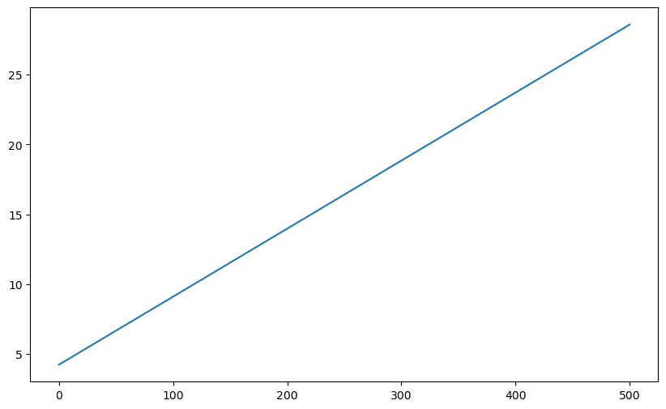

```python
plt.plot(potential_spend, predicted_sales_lin);
```

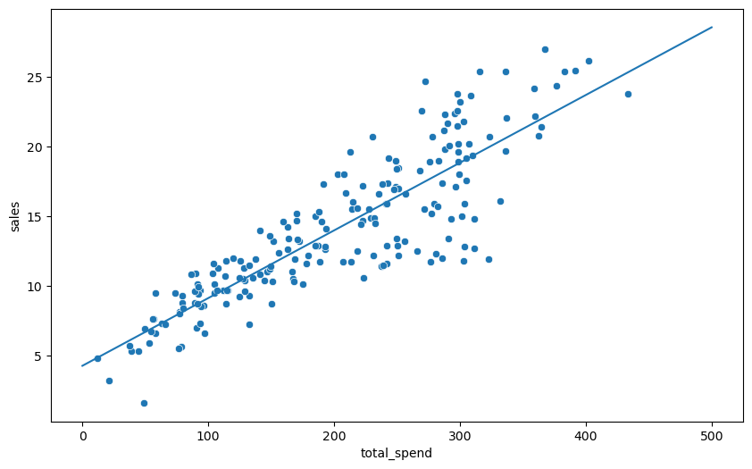

```python
plt.plot(potential_spend, predicted_sales_lin)
sns.scatterplot(x="total_spend", y="sales", data=df);
```

# How Can We Improve Our Predictions ?

y = b1 * x + b0 => simple linear

y = a1 *x ** 3 + a2* x * *2 + a3*x + a0 => 3 degree polinominal

Polinom derecesini artırarak tahmin modelini geliştirebiliriz (Model Complexity)

**Model complexity'yi artırmanın genel amacı, modelin eğitim verilerindeki daha ince desenleri ve ilişkileri yakalayabilmesini sağlamak ve böylece daha karmaşık problemleri çözebilmesidir. Ancak, model karmaşıklığını artırmanın aşırı uydurma (overfitting) gibi bazı riskleri de vardır.**

**Model complexity'yi artırma yöntemlerinden birkaçı:**

- **Feature Eklemek**: Modelinize daha fazla özellik (feature) eklemek, modelin verilerdeki daha karmaşık ilişkileri öğrenmesine olanak tanır. Ancak, gereksiz özelliklerin eklenmesi modelin performansını olumsuz etkileyebilir.
- **Modelin Derecesini Artırmak**: Özellikle lineer modellerde, özelliklerin polinom derecelerini (örneğin, kare, küp vb.) ekleyerek modelin karmaşıklığını artırabilirsiniz. Bu, modelin lineer olmayan ilişkileri yakalamasına yardımcı olur
- **Düzenlileştirme Azaltma**: Düzenlileştirme, modelin aşırı uydurmasını önlemek için kullanılan bir tekniktir. Düzenlileştirme parametrelerini azaltarak (örneğin, L1 veya L2 düzenlileştirmenin katsayısını düşürerek) modelin daha karmaşık ilişkileri öğrenmesine izin verebilirsiniz.

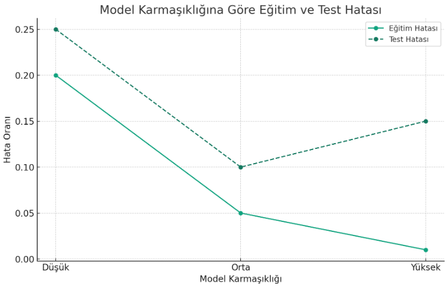

Grafik, model karmaşıklığının artmasıyla eğitim hatasının düştüğünü göstermektedir. Ancak, modelin karmaşıklığı belli bir noktadan sonra arttıkça, test hatası tekrar artmaya başlar. Bu, modelin **aşırı uydurma (overfitting)** yaşadığının bir işaretidir. Modelin karmaşıklığı arttıkça eğitim verilerine çok iyi uyum sağlar fakat genelleme yeteneği azalır, yani daha önce görmediği verilere iyi bir performans gösteremez. Bu durum, modelin karmaşıklığının ve performansının dengeli bir şekilde yönetilmesi gerektiğini gösterir.

```python
a = np.polyfit(X, y, deg=3)
a
```

```
array([ 3.07615033e-07, -1.89392449e-04,  8.20886302e-02,  2.70495053e+00])
```

Fonksiyonun döndürdüğü sonuçlar polinom katsayılarını verir.. eğer çıktı [a, b, c, d] şeklindeyse, bu bulunan en iyi uyan polinomun y = aX^3 + bX^2 + c*X + d şeklinde olduğunu gösterir.

```python
a1 = a = np.polyfit(X, y, deg=3)[0] # X^3 Teriminin Katsayısı
a2 = a = np.polyfit(X, y, deg=3)[1] # X^2 Teriminin Katsayısı
a3 = a = np.polyfit(X, y, deg=3)[2] # X Teriminin Katsayısı
a0 = a = np.polyfit(X, y, deg=3)[3] # Sabit Terim
```

```python
# üstteki kod için ilave bir çözüm de alttaki gibi olabilir
# coefficients = np.polyfit(X, y, deg = 3)
# a1 = coefficients[0]
# a2 = coefficients[1]
# a3 = coefficients[2]
# a0 = coefficients[3]
```

```python
# Polynom Function için prediction oluşturalım

#          y         =          a1X^3                   a2X^2                  a3X          a0
predicted_sales_poly = a1*potential_spend**3 + a2*potential_spend**2 + a3*potential_spend + a0
predicted_sales_poly #    -      X         -
```

```
array([ 2.70495053,  3.11474825,  3.51512185,  3.90630911,  4.28854779,
        4.66207567,  5.02713052,  5.38395012,  5.73277224,  6.07383465,
        6.40737513,  6.73363145,  7.05284138,  7.3652427 ,  7.67107317,
        7.97057058,  8.2639727 ,  8.5515173 ,  8.83344215,  9.10998502,
        9.3813837 ,  9.64787595,  9.90969955, 10.16709227, 10.42029188,
       10.66953616, 10.91506287, 11.15710981, 11.39591473, 11.63171541,
       11.86474962, 12.09525514, 12.32346974, 12.5496312 , 12.77397728,
       12.99674577, 13.21817442, 13.43850103, 13.65796336, 13.87679918,
       14.09524627, 14.3135424 , 14.53192534, 14.75063288, 14.96990277,
       15.1899728 , 15.41108073, 15.63346435, 15.85736142, 16.08300973,
       16.31064703, 16.54051111, 16.77283973, 17.00787068, 17.24584172,
       17.48699063, 17.73155518, 17.97977315, 18.23188231, 18.48812043,
       18.74872528, 19.01393464, 19.28398629, 19.55911799, 19.83956752,
       20.12557265, 20.41737116, 20.71520081, 21.01929939, 21.32990467,
       21.64725441, 21.9715864 , 22.3031384 , 22.64214819, 22.98885355,
       23.34349224, 23.70630204, 24.07752072, 24.45738606, 24.84613583,
       25.2440078 , 25.65123975, 26.06806945, 26.49473467, 26.93147319,
       27.37852277, 27.8361212 , 28.30450625, 28.78391569, 29.27458729,
       29.77675883, 30.29066808, 30.81655281, 31.3546508 , 31.90519982,
       32.46843764, 33.04460204, 33.63393079, 34.23666166, 34.85303244])
```

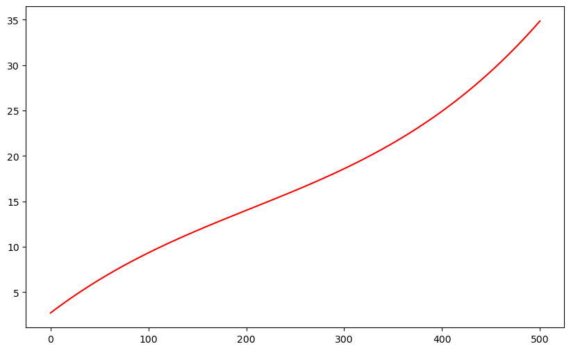

```python
plt.plot(potential_spend, predicted_sales_poly, color="red");
```

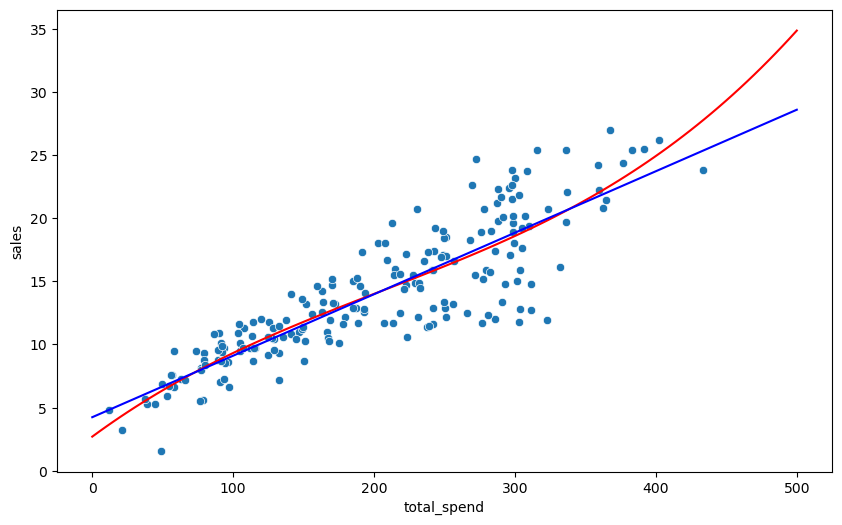

```python
plt.plot(potential_spend, predicted_sales_poly, color="red")
plt.plot(potential_spend, predicted_sales_lin, color="blue")
sns.scatterplot(x="total_spend", y="sales", data=df);
```

```python
spend = 400
sales_pred_lin = b1 * spend +b0
sales_pred_poly = a1*spend**3 + a2*spend**2 + a3*spend + a0

print(sales_pred_lin, sales_pred_poly)
```

```
23.718179943655596 24.92497283767074
```

```python
a
```

[output not shown]

**The End**